# Reading the CPS, a Fixed-Width File

> Most introductory examples regarding reading files with python involve .csv files or other kinds of files with delimiters. However fixed-width files such as the Current Population Survey are commonly used in Economic research. This notebook demonstrates how to read a fixed width file.

#### Background

- Each CPS record is 950 characters wide
- Variables are located positionally within each record.
- There are no delimiters separating one variable from another.
- Rather, a *codebook* document provides a description of variable positions
- The codebook also describes the mapping of each variables numeric value to categorial meaning

For this bootcamp, we provide two files

| Path to file | Description |
| --- | --- |
| `./bootcamp_cps/mar14pub_1k.dat` | 1,000 randomly sampled records from the March 2014 CPS |
| `./bootcamp_cps/January_2014_Record_Layout.doc` | Codebook, original MS Word Document |

### Goals

- Open CPS file, choosing selected variables
- Produce illustrative frequencies and cross-tabs

#### 0. Set Up

```python
% matplotlib inline
import pandas as pd
import numpy as np
```

```python
cps_file = './bootcamp_cps/mar14pub_1k.dat'
```

#### 1. Choose variables to load

```python
from_codebook = \
"""
GEREG			2		REGION											89 - 90
PEMARITL		2		MARITAL STATUS 								125 - 126
PERRP			2		RELATIONSHIP TO REFERENCE						118 - 119
PRTAGE			2		PERSONS AGE  									122 - 123
PESEX			2		SEX												129 - 130
PEMLR			2		MONTHLY LABOR FORCE RECODE					180 - 181
"""
```

```python
fcb_lines = from_codebook.split('\n')
```

```python
fcb_lines
```

```
['',
 'GEREG\t\t\t2\t\tREGION\t\t\t\t\t\t\t\t\t\t\t89 - 90',
 'PEMARITL\t\t2\t\tMARITAL STATUS \t\t\t\t\t\t\t\t125 - 126',
 'PERRP\t\t\t2\t\tRELATIONSHIP TO REFERENCE\t\t\t\t\t\t118 - 119',
 'PRTAGE\t\t\t2\t\tPERSONS AGE  \t\t\t\t\t\t\t\t\t122 - 123',
 'PESEX\t\t\t2\t\tSEX\t\t\t\t\t\t\t\t\t\t\t\t129 - 130',
 'PEMLR\t\t\t2\t\tMONTHLY LABOR FORCE RECODE\t\t\t\t\t180 - 181',
 '']
```

```python
codebook_dictionary = {}
for line in fcb_lines:
    if len(line):
        record = [item for item in line.split('\t') if item]
        # print record
        cps_variable = record[0]
        var_width = int(record[1])
        description = record[2]
        cps_position_string = record[-1].replace(' ','').split('-')
        cps_position_tuple = tuple([int(s) for s in cps_position_string])
        position_tuple = (cps_position_tuple[0] - 1, cps_position_tuple[0] + var_width - 1)
        # print cps_position_string, position_tuple
        codebook_dictionary[cps_variable] = position_tuple
```

```python
codebook_dictionary
```

```
{'GEREG': (88, 90),
 'PEMARITL': (124, 126),
 'PEMLR': (179, 181),
 'PERRP': (117, 119),
 'PESEX': (128, 130),
 'PRTAGE': (121, 123)}
```

```python
names = codebook_dictionary.keys()
names
```

```
['PRTAGE', 'PERRP', 'GEREG', 'PEMARITL', 'PEMLR', 'PESEX']
```

```python
positions = [codebook_dictionary.get(n) for n in names]
positions
```

```
[(121, 123), (117, 119), (88, 90), (124, 126), (179, 181), (128, 130)]
```

```python
cps = pd.read_fwf(cps_file, colspecs = positions, names = names)
```

```python
cps.head()
```

|  | PRTAGE | PERRP | GEREG | PEMARITL | PEMLR | PESEX |
| --- | --- | --- | --- | --- | --- | --- |
| 0 | 55 | 1 | 4 | 1 | 1 | 1 |
| 1 | 67 | 3 | 3 | 1 | 5 | 2 |
| 2 | 54 | 1 | 4 | 1 | 1 | 1 |
| 3 | 23 | 2 | 4 | 6 | 1 | 2 |
| 4 | 62 | 3 | 4 | 1 | 5 | 2 |

```python
region_check = cps.GEREG.value_counts()
region_check
```

```
3    337
4    257
2    222
1    184
dtype: int64
```

#### An Aside: How to order by category?

```python
region_order = region_check.index
```

```python
region_order
```

```
Int64Index([3, 4, 2, 1], dtype='int64')
```

```python
sorted_reg_ix = sorted(region_order)
sorted_reg_ix
```

```
[1, 2, 3, 4]
```

```python
region_check[sorted_reg_ix]
```

```
1    184
2    222
3    337
4    257
dtype: int64
```

### Check against Bash to make sure we are counting the right thing

```python
%%bash
cut -c 89-90 bootcamp_cps/mar14pub_1k.dat | sort | uniq -c
```

```
 184  1
 222  2
 337  3
 257  4
```

### Assign Category Values

```python
region_codes = {1: "Northeast", 2:"Midwest", 3:"South", 4: "West"}
sex_codes = {1: "Male", 2: "Female"}
marital_status_codes = {1: "Married - Spouse Present",
                        2: "Married - Spouse Absent",
                        3: "Widowed", 4: "Divorced", 5: "Separated",
                        6: "Never Married"}
```

```python
cps['region'] = [region_codes.get(r) for r in cps['GEREG']]
cps['sex'] = [sex_codes.get(r) for r in cps['PESEX']]
cps['marital_status'] = [marital_status_codes.get(r) for r in cps['PEMARITL']]
```

```python
cps.head()
```

|  | PRTAGE | PERRP | GEREG | PEMARITL | PEMLR | PESEX | region | sex | marital_status |
| --- | --- | --- | --- | --- | --- | --- | --- | --- | --- |
| 0 | 55 | 1 | 4 | 1 | 1 | 1 | West | Male | Married - Spouse Present |
| 1 | 67 | 3 | 3 | 1 | 5 | 2 | South | Female | Married - Spouse Present |
| 2 | 54 | 1 | 4 | 1 | 1 | 1 | West | Male | Married - Spouse Present |
| 3 | 23 | 2 | 4 | 6 | 1 | 2 | West | Female | Never Married |
| 4 | 62 | 3 | 4 | 1 | 5 | 2 | West | Female | Married - Spouse Present |

## Frequency Table

```python
cps.PRTAGE.value_counts(bins=10)
```

```
-1.086     210
 50.600    114
 33.400    102
 7.600     102
 24.800    101
 59.200     93
 42.000     88
 16.200     86
 67.800     56
 76.400     48
dtype: int64
```

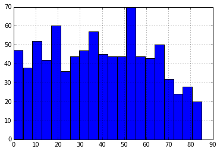

```python
# Age Distribution, excluding those coded as '-1'
cps.PRTAGE[cps.PRTAGE != -1].hist(bins=20)
```

### Cross-Tabs

```python
# Counts
frequencies = pd.crosstab(cps.sex, cps.region)
frequencies
```

| region sex | Midwest | Northeast | South | West |
| --- | --- | --- | --- | --- |
| Female | 97 | 84 | 158 | 116 |
| Male | 99 | 75 | 125 | 113 |

```python
# Colum Percentages (axis=0)
col_pcts = pd.crosstab(cps.sex, cps.region).apply(lambda r: r/r.sum(), axis=0)
col_pcts
```

| region sex | Midwest | Northeast | South | West |
| --- | --- | --- | --- | --- |
| Female | 0.494898 | 0.528302 | 0.558304 | 0.50655 |
| Male | 0.505102 | 0.471698 | 0.441696 | 0.49345 |

```python
tab1 = pd.crosstab(cps.sex, cps.region)
tab1['Row_Sum'] = tab1.sum(axis=1)
tab1
```

| region sex | Midwest | Northeast | South | West | Row_Sum |
| --- | --- | --- | --- | --- | --- |
| Female | 97 | 84 | 158 | 116 | 455 |
| Male | 99 | 75 | 125 | 113 | 412 |

```python
tab1.sum(axis=0, name="Col_Sum")
```

```
region
Midwest      196
Northeast    159
South        283
West         229
Row_Sum      867
dtype: int64
```

```python
# extend dataframe using .loc method
tab1.loc["Col_Sum",:] = tab1.sum(axis=0, name="Col_Sum")
```

```python
tab1
```

| region sex | Midwest | Northeast | South | West | Row_Sum |
| --- | --- | --- | --- | --- | --- |
| Female | 97 | 84 | 158 | 116 | 455 |
| Male | 99 | 75 | 125 | 113 | 412 |
| Col_Sum | 196 | 159 | 283 | 229 | 867 |

### Chi-squared test for a cross-tab

```python
from scipy.stats import chisquare
```

```python
observed = np.array(frequencies)
```

```python
expected = (np.sum(observed) * np.ones(observed.shape)) / (observed.shape[0] * observed.shape[1])
```

```python
observed
```

```
array([[ 97,  84, 158, 116],
       [ 99,  75, 125, 113]])
```

```python
expected
```

```
array([[ 108.375,  108.375,  108.375,  108.375],
       [ 108.375,  108.375,  108.375,  108.375]])
```

```python
# chi-squared test on distribution of M and F
chisquare(observed, axis=1)
```

```
(array([ 27.50549451,  13.4368932 ]),
 array([  4.61226271e-06,   3.78103850e-03]))
```

```python
# chi-suqared test on distribution of region
chisquare(observed, axis=0)
```

```
(array([ 0.02040816,  0.50943396,  3.84805654,  0.03930131]),
 array([ 0.88640301,  0.47538399,  0.04980367,  0.84285293]))
```

```python
# chi-squared test on overall frequencies
chisquare(observed, axis=None)
```

```
(43.772779700115336, 2.3648444893647314e-07)
```

```python
# Chi-square test on uniformly-distributed data
chisquare(expected, axis=None)
```

```
(0.0, 1.0)
```

Read more about Python chi-square test here: http://docs.scipy.org/doc/scipy/reference/generated/scipy.stats.mstats.chisquare.html

## LaTeX example...

\begin{aligned} C_t &= \alpha_0 + \alpha_1 P_t + \alpha_2 P_{t-1} + \alpha_3(W^p_t + W^g_t) + \epsilon_{1t} \\ I_t &= \beta_0 + \beta_1 P_t + \beta_2 P_{t-1} + \beta_3 K_{t-1} + \epsilon_{2t} \\ W^p_t &= \gamma_0 + \gamma_1 X_t + \gamma_2 X_{t-1} + \gamma_3 A_t + \epsilon_{3t} \\ K_t &= K_{t-1} + I_t \end{aligned}

\begin{aligned} S_{i+1} = S_i e^{-\lambda\delta} + \mu(1-e^{-\lambda\delta}) + \sigma \sqrt{\frac{1 - e^{-2\lambda\delta}}{2\lambda}} N_{0,1} \end{aligned}